# non-coding RNAs metadata gathering

Camilla Canovi & Nicolas Delhomme

2021-07-29

# 1 Setup

Libraries

```r
suppressPackageStartupMessages({
  library(Biostrings)
  library(here)
  library(magrittr)
  library(parallel)
  library(tidyverse)
  library(tximport)
})
```

Helper functions

```r
source(here("UPSCb-common/src/R/expressionSpecificityUtility.R"))
```

# 2 Data

## 2.1 Salmon

```r
salmon <- list.files(here("data/Salmon"),
                          recursive = TRUE,
                          pattern = "quant.sf",
                          full.names = TRUE)

counts <- suppressMessages(round(tximport(files = salmon,
                                          type = "salmon",
                                          txOut=TRUE)$counts))

colnames(counts) <- sub(".*/","",sub("_L00[1,2]_sort.*","",
                                     sub("[1,2]_[1].*_.*DXX_","",
                                         sub("_dual.*","",salmon))))
```

Combine the technical replicates

```r
counts <- sapply(split.data.frame(t(as.data.frame(counts)),colnames(counts)),colSums)
```

## 2.2 stage specificity

```r
load(here("data/analysis/DE/vst-aware.rda"))
samples_m <- read.csv(here("doc/samples.csv"))
time_expression <- expressionSpecificity(
  exp.mat = vsta,
  tissues = as.character(samples_m$Stages[match(colnames(vsta),samples_m$SampleID)]),
  output = "complete")
```

```
## Calculating tissue specificity
```

Visualisation

- expression is either very stage specific (peak at 1) or spreading between 0 and 0.6 (rather ubiquitous)

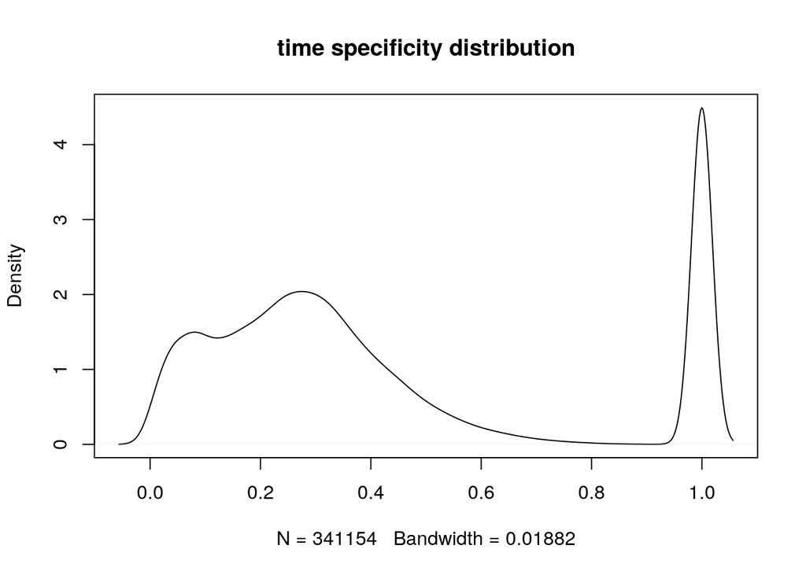

```r
plot(density(time_expression[!is.na(time_expression[,"score"]),"score"]),
     main="time specificity distribution")
```

- the expression for stage specific gene is on average low

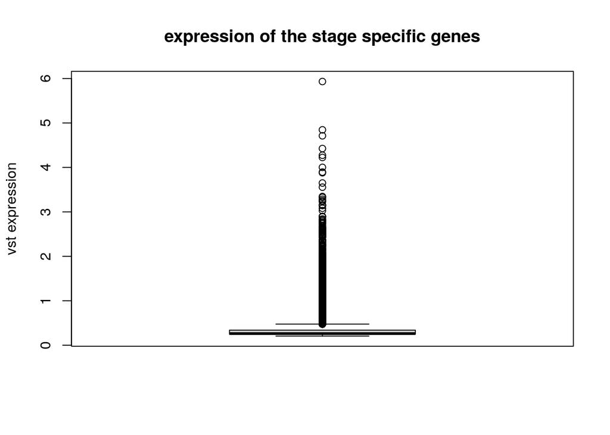

```r
boxplot(time_expression[time_expression[,"score"]==1,"maxn"],
        main="expression of the stage specific genes",ylab="vst expression")
```

- the expression of gene with a stage specificity >= 0.9 is as expected mostly within a single stage but can spread to as much as all (8) stages

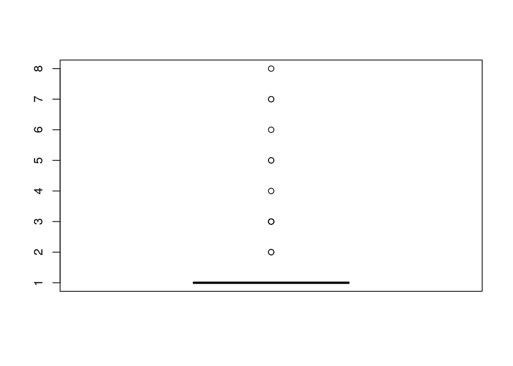

```r
boxplot(time_expression[time_expression[,"score"]>=0.9,"n"])
```

here is the example

```r
time_expression[time_expression[,"score"]>=0.9 & time_expression[,"n"]==8,]
```

```
##                           score    aij.S1    aij.S2   aij.S3    aij.S4
## TRINITY_DN60_c0_g2_i4 0.9309307 0.6982826 0.4782186 0.420926 0.5031086
##                          aij.S5    aij.S6   aij.S7  aij.S8    maxn n peak
## TRINITY_DN60_c0_g2_i4 0.3267492 0.3963964 1.172224 8.26479 8.26479 8   S8
```

Some summary statistics

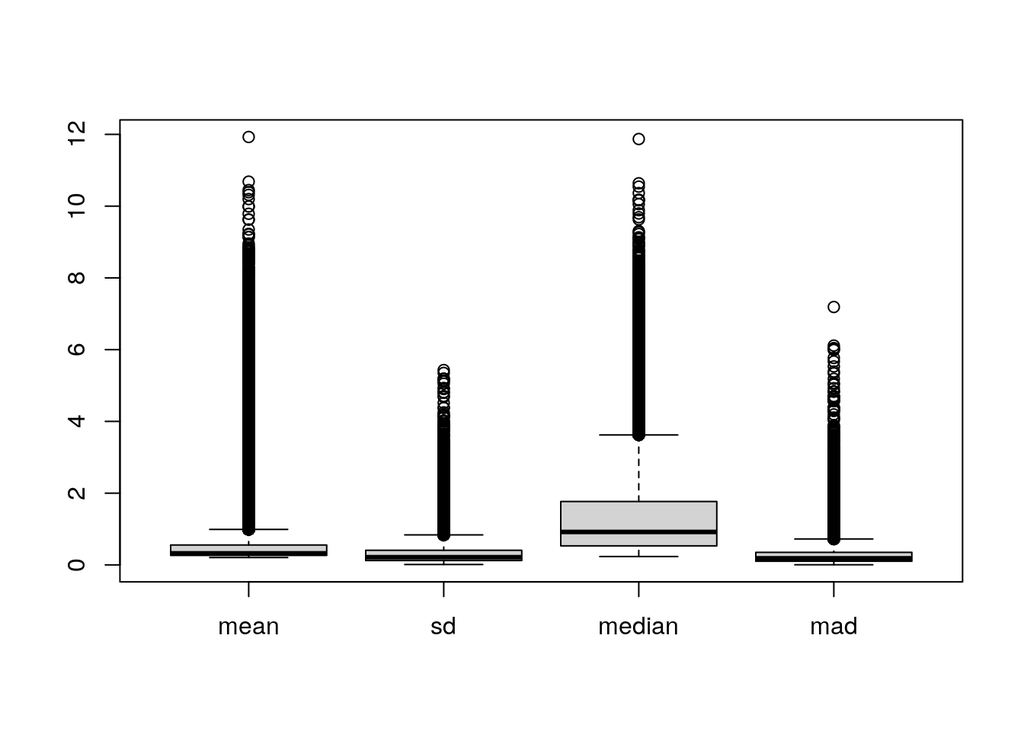

```r
means <- rowMeans2(as.matrix(time_expression[,grep("aij",colnames(time_expression),value=TRUE)]),na.rm = TRUE)
median <- rowMedians(as.matrix(time_expression[,grep("aij",colnames(time_expression),value=TRUE)]))
sd <- rowSds(as.matrix(time_expression[,grep("aij",colnames(time_expression),value=TRUE)]))
mad <- rowMads(as.matrix(time_expression[,grep("aij",colnames(time_expression),value=TRUE)]))
boxplot(list(mean=means,sd=sd,median=median,mad=mad))
```

Start a tibble to store the metadata

```r
metadata <- left_join(as.data.frame(counts) %>% rownames_to_column("TRINITY_ID"),
                      as.data.frame(time_expression) %>% rownames_to_column("TRINITY_ID"),
                      by="TRINITY_ID") %>% as_tibble()
```

## 2.3 GMAP

Process all three file types, concatenate the loci if needed and report per trinity ID, including a type column

```r
metadata %<>% left_join(reduce(mclapply(list.files(here("data/GMAP"),
                             pattern="*_gene",
                             recursive=FALSE,
                             full.names=TRUE),
                  function(f){
                    read_table2(f,
                                col_names = c("Gene","X2","X3",
                                              "start","end","X6","strand","X8","TRINITY_ID"),
                                col_types = cols_only("Gene" = col_character(),
                                                      "start" = col_double(),
                                                      "end" = col_double(),
                                                      "strand" = col_character(),
                                                      "TRINITY_ID" = col_character())) %>%
                      unite(Gene,start,end,strand,col="gmap_loc",sep="_") %>%
                      mutate(TRINITY_ID=sub(".*=","",TRINITY_ID)) %>%
                      group_by(TRINITY_ID) %>%
                      summarise(gmap_loc=paste(gmap_loc,collapse="|")) %>%
                      mutate(gmap_type=sub("_gene","",basename(f)))
                  },mc.cores=3L),bind_rows),by="TRINITY_ID")
```

## 2.4 BedToolsIntersect

```r
metadata %<>% left_join(read_table2(here("data/GMAP/BedToolsIntersect2/GMAP_all-Eugene-gene-only.tsv"),
                          col_names = c("scaffold","X2","X3",
                                        "X4","X5","X6","X7","X8","TRINITY_ID",
                                        "X10","X11","X12","start","end","X15",
                                        "strand","X17","GENE_ID","intersect_length"),
                          col_types = cols_only(scaffold=col_character(),
                                                "TRINITY_ID" = col_character(),
                                                "start" = col_double(),
                                                "end" = col_double(),
                                                "strand" = col_character(),
                                                "GENE_ID" = col_character(),
                                                "intersect_length" = col_double())) %>%
  mutate(gene_intersect_percent=round(intersect_length/(end-start+1)*100,digits=2)) %>%
  unite(scaffold,start,end,strand,col="intersect_loc",sep="_") %>%
  mutate(TRINITY_ID=sub(".*=","",TRINITY_ID),
         GENE_ID=sub(".*=","",GENE_ID))%>%
  group_by(TRINITY_ID) %>%
  summarise_all(paste,collapse="|"),by="TRINITY_ID")
```

## 2.5 BedToolsSubtract

```r
metadata %<>% left_join(read_table2(here("data/GMAP/BedToolsSubtract/GMAP_all-Eugene-gene-only_no-self_no-full-overlap.gff3"),
                        col_names = c("scaffold","X2","X3",
                                      "t_start","t_end","X6","X7","X8","TRINITY_ID",
                                      "X10","start","end",
                                      "X13","X14",
                                      "strand","subtract_length"),
                        col_types = cols_only("scaffold" = col_character(),
                                              "t_start" = col_double(),
                                              "t_end" = col_double(),
                                              "TRINITY_ID" = col_character(),
                                              "start" = col_double(),
                                              "end" = col_double(),
                                              "strand" = col_character(),
                                              "subtract_length" = col_double())) %>%
  mutate(trinity_subtract_percent=round(subtract_length/(t_end-t_start+1)*100,digits=2)) %>%
  unite(scaffold,start,end,strand,col="subtract_loc",sep="_") %>%
  mutate(TRINITY_ID=sub(".*=","",TRINITY_ID))%>%
  group_by(TRINITY_ID) %>%
  summarise_all(paste,collapse="|"),by="TRINITY_ID")
```

There are about 200 thousands without any overlap, while there are trinity IDs that intersect a gene than can be subtracted (i.e. some are wholly contained).

```r
table(subtract=!is.na(metadata$trinity_subtract_percent),
      intersect=!is.na(metadata$gene_intersect_percent))
```

```
##         intersect
## subtract  FALSE   TRUE
##    FALSE 199316  94535
##    TRUE       0  93517
```

## 2.6 trmap

```r
metadata %<>% left_join(reduce(mclapply(list.files(here("data/trmap/trinity"),
                           full.names=TRUE,
                           pattern="trmapIDs.txt",
                           recursive=TRUE),
                function(f){
                  tibble(TRINITY_ID=scan(f,what="character"),
                         trmap_from=basename(dirname(f)))
                },mc.cores=3L),bind_rows) %>% distinct(),by="TRINITY_ID")
```

All the trmap are also contained in the bedtools intersect, however there are about 50,000 more that are not identified by trmap, because the intersect is probably too small

```r
table(trmap=!is.na(metadata$trmap_from),
      intersect=!is.na(metadata$gene_intersect_percent))
```

```
##        intersect
## trmap    FALSE   TRUE
##   FALSE 199316  49263
##   TRUE       0 138789
```

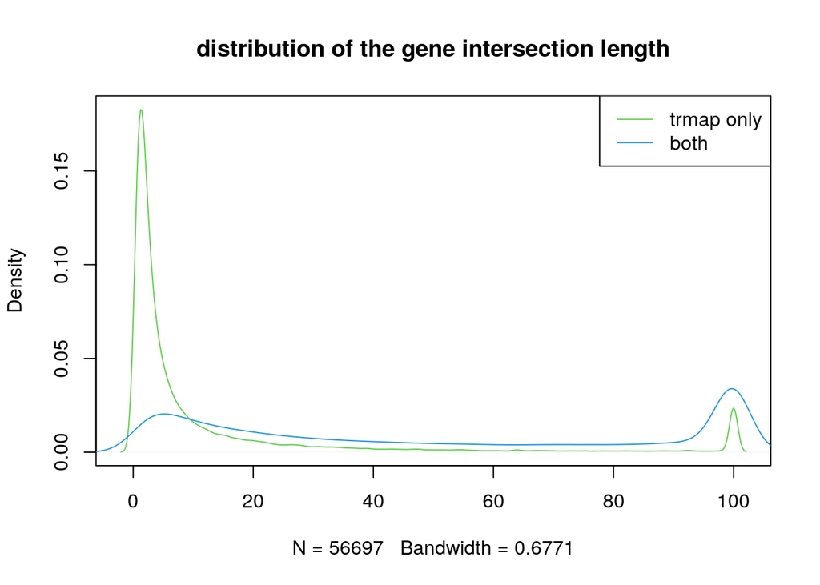

```r
plot(density(as.numeric(
  unlist(strsplit(metadata$gene_intersect_percent[
    is.na(metadata$trmap_from) &
      !is.na(metadata$gene_intersect_percent)],"\\|")))),
  col=3,main="distribution of the gene intersection length")
lines(density(as.numeric(
  unlist(strsplit(metadata$gene_intersect_percent[
    !is.na(metadata$trmap_from) &
      !is.na(metadata$gene_intersect_percent)],"\\|")))),col=4)
legend("topright",lty=1,col=c(3,4),c("trmap only","both"))
```

## 2.7 Diamond

```r
metadata %<>% left_join(read_table2(here("data/DIAMOND/uniref90.dmnd_Trinity.blt.gz"),
                       col_names = c("TRINITY_ID", "reference_ID",
                                     "identity", "alignment_length", "mismatch",
                                     "gap_open", "start_trinity", "end_trinity",
                                     "start_ref", "end_ref",
                                     "evalue", "bitscore", "trinity_length",
                                     "ref_length", "taxonomy")) %>%
  mutate(trinity_cov=alignment_length/trinity_length,
         ref_cov=alignment_length/ref_length,
         TRINITY_ID=sub("\\.p[0-9]+","",TRINITY_ID)) %>%
  group_by(TRINITY_ID) %>%
  arrange(desc(identity),desc(trinity_cov),desc(ref_cov)) %>%
  slice(1) %>% ungroup(),by="TRINITY_ID")
```

## 2.8 Taxonomy

We extract the UniRef ID

```r
uniref_id <- unique(metadata$reference_ID[!is.na(metadata$reference_ID)])
```

Create a function

```r
f<-function(lines,pos){
    return(lines[lines$reference_ID %in% uniref_id,])
}
```

To parse the input data on the fly (if the txt file is compressed, decompress it prior to running that line, as oytherwise R will do the decompression in mem, loosing the advantage of chunking)

```r
tax_map <- read_delim_chunked(col_names=c("reference_ID","taxon","taxID"),
                            col_types=c("ccc"),
                            here("uniref/annotation/uniref90_id-table.txt"),
                            chunk_size=1e6,delim=" ",callback=DataFrameCallback$new(f))
```

A quick look at the top species

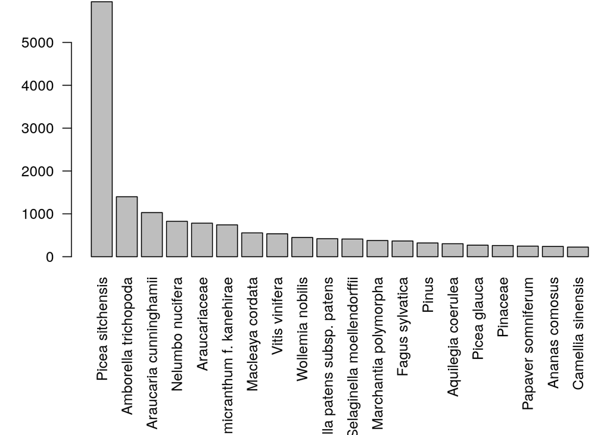

```r
mar <- par("mar")
par(mar=c(10.1,4.1,0.1,0.1))
barplot(sort(table(tax_map$taxon),decreasing=TRUE)[1:20],las=2)
```

```r
par(mar=mar)
```

Extend the metadata

```r
metadata %<>% left_join(tax_map,by="reference_ID")
```

## 2.9 Sequences

```r
ref <- readDNAStringSet(here("data/trinity/Trinity.fasta"))
metadata %<>% left_join(tibble(TRINITY_ID=sub(" .*","",names(ref)),
                               GC=rowSums(alphabetFrequency(ref)[,c("C","G")]) / width(ref),
                               length=width(ref)),by="TRINITY_ID")
```

## 2.10 CNCI

```r
metadata %<>% left_join(read_tsv(file = here("data/CNCI/CNCI.index"),
                                 col_names = c("TRINITY_ID", "CNCI_index", "CNCI_score", "CNCI_start", "CNCI_end", "CNCI_length"),
                                 col_types=cols(.default=col_character())) %>%
                          mutate(TRINITY_ID=gsub(">| .*","",TRINITY_ID)),by="TRINITY_ID")
```

## 2.11 PLEK

```r
metadata %<>% left_join(read_tsv(file=here("data/PLEK/Trinity.txt"),
                                 col_names = c("PLEK_type","PLEK_score","TRINITY_ID"),
                                 col_types = c("cdc")) %>%
                          mutate(TRINITY_ID=gsub(">| .*","",TRINITY_ID)),by="TRINITY_ID")
```

## 2.12 CPC2

```r
metadata %<>% left_join(read_tsv(file = here("data/CPC2/results.txt"),
                                 comment="#",
                                 col_names = c("TRINITY_ID",
                                               "CPC2_transcript_length",
                                               "CPC2_peptide_length",
                                               "CPC2_Fickett_score",
                                               "CPC2_pI",
                                               "CPC2_ORF_integrity",
                                               "CPC2_coding_probability" ,
                                               "CPC2_label"),
                                 col_types=c("cddddddc")),by="TRINITY_ID")
```

## 2.13 PLncPRO

```r
metadata %<>% left_join(read_table2(file = here("data/PLncPRO/Trinity.txt"),
                                    col_names = c("TRINITY_ID","PLncPRO_coding_potential","X3","X4"),
                                    col_types = cols_only("TRINITY_ID"=col_character(),
                                                          "PLncPRO_coding_potential"=col_number())),by="TRINITY_ID")
```

## 2.14 Transdecoder

```r
metadata %<>% left_join(read_table2(here("data/Transdecoder/Trinity.fasta.transdecoder.IDs.txt"),
                                    col_names = c("X1","X2","X3",
                                                  "Transdecoder_type","Transdecoder_AA_length","Transdecoder_score","Coord"),
                                    col_types = cols_only("Transdecoder_type"=col_character(),
                                                          "Transdecoder_AA_length"=col_number(),
                                                          "Transdecoder_score"=col_character(),
                                                          "Coord"=col_character())) %>%
                          separate(Coord,into=c("TRINITY_ID","Transdecoder_start","Transdecoder_end"),extra="drop",sep=":|=|-|\\(") %>%
                          mutate(Transdecoder_type=factor(sub("type:","",Transdecoder_type)),
                                 Transdecoder_strand=gsub("\\(|\\).*","",Transdecoder_score),
                                 Transdecoder_score=parse_double(sub(".*=","",Transdecoder_score))),by="TRINITY_ID")
```

# 3 Flagging

- Coding

```r
metadata %<>% mutate(coding=length >= 200 &
                       CNCI_index == "coding" &
                       PLEK_type == "Coding" &
                       CPC2_label == "coding" &
                       PLncPRO_coding_potential == 1 &
                       !is.na(Transdecoder_type))
```

- Non-coding

```r
metadata %<>% mutate(non_coding=length >= 200 &
                       CNCI_index == "noncoding" &
                       PLEK_type == "Non-coding" &
                       CPC2_label == "noncoding" &
                       PLncPRO_coding_potential == 0)
```

- Network

```r
metadata %<>% mutate(seidr=TRINITY_ID %in% scan(here("data/seidr/genes.tsv"),sep="\t",what="character"))
```

# 4 Export

```r
write_tsv(metadata,file=here("data/metadata.tsv"))
```